# Project 4 - Recommender System

Student: Gunther Correia Bacellar, NetID: gunther6

CS598, Fall 2020

In this project we will explore different movie recommendation systems using the MovieLens dataset with 1 million anonymous ratings of approximately 3,900 movies made by 6,040 users.

# 1. Exploratory Data Analysis

### 1.1 Read and preprocess movies dataset

```r
set.seed(1234)
library(dplyr)
library(ggplot2)
library(recommenderlab)
library(DT)
library(data.table)
library(reshape2)
library(patchwork)
library(tidyr)
library(stringr)

myurl = "https://liangfgithub.github.io/MovieData/"
ratings = read.csv(paste0(myurl, 'ratings.dat?raw=true'), sep = ':',
                   colClasses = c('integer', 'NULL'), header = FALSE)
colnames(ratings) = c('UserID', 'MovieID', 'Rating', 'Timestamp')
movies = readLines(paste0(myurl, 'movies.dat?raw=true'))
movies = strsplit(movies, split = "::", fixed = TRUE, useBytes = TRUE)
movies = matrix(unlist(movies), ncol = 3, byrow = TRUE)
movies = data.frame(movies, stringsAsFactors = FALSE)
colnames(movies) = c('MovieID', 'Title', 'Genres')
movies$MovieID = as.integer(movies$MovieID)
movies$item = paste0("i",movies$MovieID)
movies$Title = iconv(movies$Title, "latin1", "UTF-8")
movies$Year = as.numeric(unlist(
  lapply(movies$Title, function(x) substr(x, nchar(x)-4, nchar(x)-1))))
dim(movies)
```

```
## [1] 3883    5
```

The dataset movies includes 3883 films from the years 1919 to 2000

### 1.2 Preprocess ratings dataset

```r
# define the minimal number of ratings a movie should have to be considered in the recommendation analysis
n_ratings_cutoff = 50
clean_rating = ratings %>%
           mutate(user = paste0("u", UserID), item = paste0("i", MovieID))
n_item = clean_rating %>% group_by(item) %>% summarize (n = n()) %>% arrange(n)
n_item$pos = 1:nrow(n_item)
clean_rating = clean_rating %>%
               semi_join(n_item %>% filter(n>=n_ratings_cutoff))
avg_rating = clean_rating %>% group_by(MovieID) %>% summarize(avg_rating = mean(Rating), n=n()) %>% arrange(-avg_rating)

# save only the rating summary to be used in the Shiny App to avoid reading a large rating dataset again
write.csv(avg_rating,
          "C:/Gunther/OneDrive - University of Illinois - Urbana/Documents/Github/Movies/avg_rating.csv",
          row.names = FALSE)
movies = movies %>% inner_join(avg_rating, by = "MovieID")
# calculate how many movies are excluded from the dataset
movies_excl = as.numeric(table(n_item$n<n_ratings_cutoff)[2])
movies_excl_rat = sum(n_item[1:movies_excl,"n"])
ratings_matrix = clean_rating %>% select(user, item, Rating)
# create the disperse matrix to be used by the different collaborative recommendation algorithms
ratings_matrix = as(ratings_matrix, "realRatingMatrix")
dim(ratings_matrix)
```

```
## [1] 6040 2514
```

Ratings dataset include more than 1M of observations for 3706 movies.

To avoid that a small number of users influence the move rating significantly, I excluded the movies with less than 50 ratings. This also solves the problem of observations in the movies dataset with no ratings what would generate a rating matrix with different column dimension between the matrix used to train the model and the matrix used to predict missing ratings.

### 1.3 Show representation of movies and reviews excluded

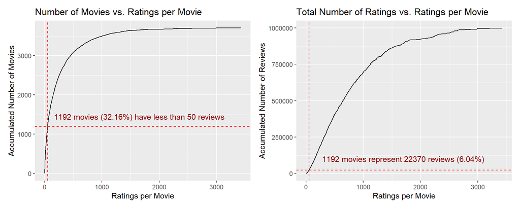

Figure 1. Understand number of movies removed

```r
plot1 = ggplot(data = n_item, aes(y = pos, x = n)) +
  geom_line() + geom_vline(xintercept = n_ratings_cutoff, linetype = 2, color = "red") +
  geom_hline(yintercept = movies_excl, linetype = 2, color = "red") +
  annotate(geom = "text", x = 1650, y=1450, color = "darkred",
           label = paste0(movies_excl, " movies (",
           round(100*movies_excl/nrow(n_item),2),"%) have less than ", n_ratings_cutoff, " reviews")) +
  labs(x = "Ratings per Movie", y="Accumulated Number of Movies", title = "Number of Movies vs. Ratings per Movie")
plot2 = ggplot(data = n_item, aes(y = cumsum(n), x = n)) +
  geom_line() + geom_vline(xintercept = n_ratings_cutoff, linetype = 2, color = "red") +
  geom_hline(yintercept = movies_excl_rat, linetype = 2, color = "red") +
  annotate(geom = "text", x = 1700, y=100000, color = "darkred",
           label = paste0(movies_excl, " movies represent ",
                          movies_excl_rat, " reviews (",round(movies_excl_rat/nrow(n_item),2),"%)")) +
  labs(x = "Ratings per Movie", y = "Accumulated Number of Reviews", title = "Total Number of Ratings vs. Ratings per Movie")
plot1 + plot2
```

#### 1.4 Histogram of distributions

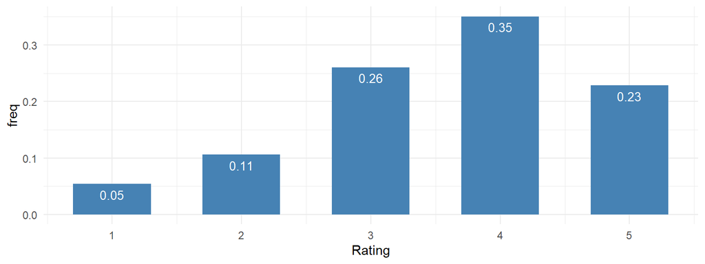

Figure 2. Histogram of rating distributions

```r
tmp = data.frame(Rating = 1:5,
                 freq = as.vector(table(clean_rating$Rating)/nrow(clean_rating)))
ggplot(data = tmp, aes(x = Rating, y = freq)) +
  geom_bar(stat="identity", fill = 'steelblue', width = 0.6) +
  geom_text(aes(label=round(freq, dig=2)), vjust=1.6, color="white", size=3.5) +
  theme_minimal()
```

# 2. System I: Recommendation Based on Genre

For the first system, I will provide two recommendation schemes for a user that is interested in movies recommendations of the genre horror.

## 2.1 Recommendation 1

In the first scheme, I will recommend the top-six highly-rated Horror movies defined based on the highest average ratings produced between 1970 and 2000. To avoid individual users to influence the ratings too much, I only considered movies rated by at least 50 other users by using the dataset movies that was already filtered (n>=50) and captured information about average ratings.

```r
genre = "Horror"
genre_result = movies  %>%
  filter(Year>=1970, grepl(genre, Genres)) %>%
  select(Title, Genres, avg_rating, Year) %>%
  arrange(-avg_rating)
genre_result[1:6,]
```

|  | Title | Genres | avg_rating | Year |
| --- | --- | --- | --- | --- |
| 1 | Young Frankenstein (1974) | Comedy\|Horror | 4.250629 | 1974 |
| 2 | Alien (1979) | Action\|Horror\|Sci-Fi\|Thriller | 4.159585 | 1979 |
| 3 | Shining, The (1980) | Horror | 4.104876 | 1980 |
| 4 | Jaws (1975) | Action\|Horror | 4.089570 | 1975 |
| 5 | Exorcist, The (1973) | Horror | 3.955932 | 1973 |
| 6 | Ghostbusters (1984) | Comedy\|Horror | 3.905548 | 1984 |

## 2.2 Recommendation 2

For this second scheme, I will recommend the top-six most popular pure-horror movies using the recommender algorithm “POPULAR” from recommenderlab package. The term pure-horror here means only movies that has the main genre (first classification) as horror. This assumes that having horror as first genre classification has more relevance to select genuine and scaring horror-movies, creating better recommendations.

“POPULAR” recommender algorithm uses a simple average of existing ratings per movie plus the average of item ratings added for prediction. This recommendation doesn’t change with some new ratings. As I am not predicting new input ratings, I used the topN items provided by POPULAR recommender and listed the top 6 values.

```r
df_genre = movies %>% filter(str_sub(Genres, 1, str_length(genre)) == genre) %>%
  left_join(clean_rating, by = "MovieID") %>%
  mutate(user = paste0("u", UserID), item = paste0("i", MovieID), rating = Rating) %>%
  select(user, item, rating)
genre_matrix = as(df_genre, "realRatingMatrix")
r = Recommender(as(df_genre, "realRatingMatrix"), method = "POPULAR")
top_popular = as(getModel(r)$topN, "list")[[1]][1:6]
top_popular = data.frame(item = top_popular)
top_popular = top_popular %>% left_join(movies, by = "item")
# Show top
top_popular[1:6,c("Title", "Genres")]
```

|  | Title | Genres |
| --- | --- | --- |
| 1 | Psycho (1960) | Horror\|Thriller |
| 2 | Shining, The (1980) | Horror |
| 3 | Exorcist, The (1973) | Horror |
| 4 | Misery (1990) | Horror |
| 5 | Sleepy Hollow (1999) | Horror\|Romance |
| 6 | Birds, The (1963) | Horror |

In this second recommendation we see that movies like “Young Frankenstein” and “Ghostbusters”, although classified as horror, have comedy as their first genre classification. Called these movies as horror may sound a bit strange if someone is looking for a pure and scaring horror movie, making the recommendation 2 more selected and avoid some surprise with genre classifications.

# 3. System II: Collaborative Recommendation System

## 3.1 Compare recommender algorithms

As collaborative recommendation system, I analyzed 3 different algorithms:

- UBCF: Recommender based on user-based collaborative filtering, which predicts ratings based on the similarity of a new user with each existing users. The average ratings of the missing items are defined based on these existing users, using or not weighed values for their similarity.
- IBCF: Recommender based on item-based collaborative filtering, which predict ratings based on the proximity of similar items. The similarity of ratings for all pair of items is calculated, the k most similar items are identified, and for each user, the items with best match are included.
- SVD: Recommender based on SVD approximation with column-mean imputation and it uses a matrix factorization-based algorithm. It is fast and became more popular when it used in the Netflix $1million competition by Simon Funk.

For UBCF and IBCF, different similarity methods are available, including “cosine” and “pearson”. For the analysis in this report, I used the standard similarity value “cosine”. In addition, it is possible to specify different values for the normalization for UBCF and IBCF, including “center” (mean of ratings are subtracted from every rating) and “z-score” (normal distribution). I also adopted the standard normalize value “center” for the rating matrix. This means that no normalization is necessary as the recommenderlab functions use “center” normalization.

Only in terms of benchmark, I added two algorithms below, but they are not good candidates for System II:

- RANDOM: Algorithm that produces random recommendations. It was added here to work as a benchmark for comparasion with other algorithms.
- POPULAR: Recommender based on item popularity, which uses a simple average of existing ratings per movie plus the average of item ratings added for prediction.

Different metrics are available to measure accuracy/error of these models, including RMSE, MSE and MAE. I chose RMSE, which was also used as metric in the $1M Netflix competition (recommender system).

To evaluate the prediction performance, I used 10 iterations, and for each iteration I split the dataset in 80% training data and 20% test data using recommenderlab’s function evaluationscheme. I also used goodRating as 0 (center of the normalized rating value) and the Given-3 protocol, where three randomly selected items are withheld for evaluation.

```r
set.seed(1234)
iter = 10
results = vector(mode = "list", length = iter)
df = data.frame(iter = rep(0,iter), model = rep(0,iter),
                RMSE = rep(0,iter), MSE = rep(0,iter),
                MAE = rep(0,iter))
count = 0
for (i in 1:iter) {
    t1 = Sys.time()
    scheme = evaluationScheme(ratings_matrix,
                              method="split",
                              train = 0.80,
                              given=3,
                              goodRating = 0)
    model = list("Random"  = list(name="Random",  param=NULL),
                 "Popular" = list(name="Popular", param=NULL),
                 "UBCF"    = list(name="UBCF",    param=list(nn=50)),
                 "IBCF"    = list(name="IBCF",    param=list(k=50)),
                 "SVD"     = list(name="SVD",     param=list(k=50)))
    results[[i]] = evaluate(scheme, model, type = "ratings", progress = FALSE)
    for (k in 1:length(model)) {
          count = count+1
          df[count, 3:5] = unlist(avg(results[[i]])[k])
          df[count, 1] = i
          df[count, 2] = model[[k]]$name
    }
    Sys.time() - t1
}
```

### 3.2 Plot comparasion of all algorithms

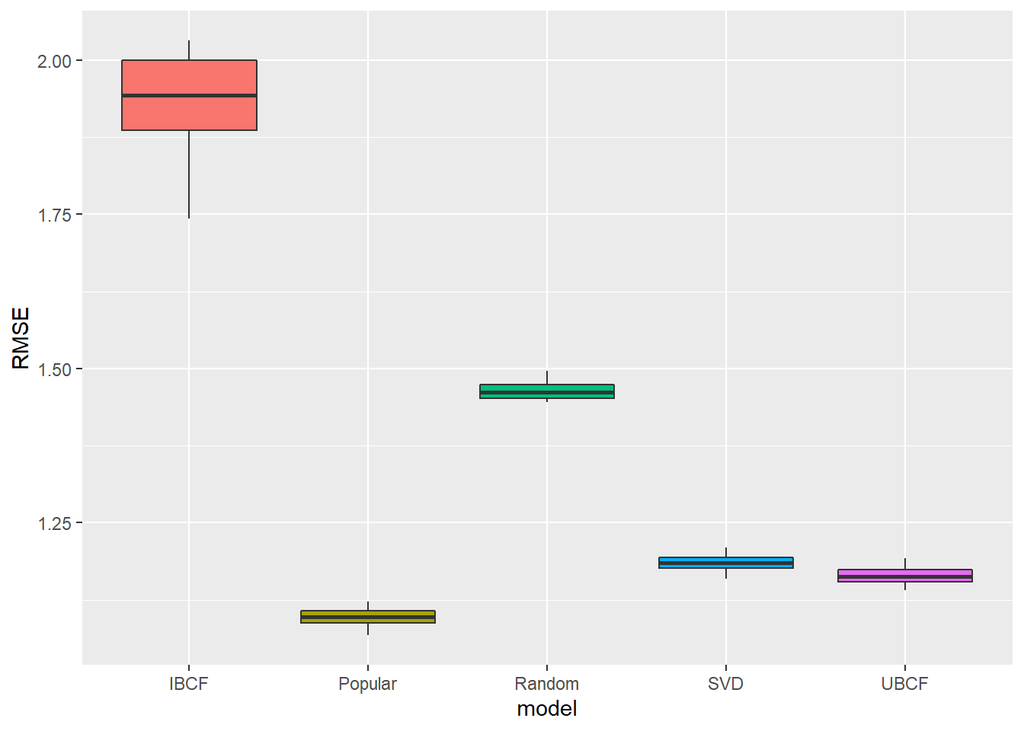

Figure 3. RMSE for 5 recommender models using 10 iterations

```r
ggplot(df, aes(x = model, y=RMSE, fill = model)) + geom_boxplot() + guides(fill=FALSE)
```

Figure 3 shows that the POPULAR, SVD and UBCF algorithms had the best RMSE results, not too far from each other, with small variance in the values using 10 iterations.

IBCF showed a high RMSE median, with high variance, so I discarded this method. I also discarded the RANDOM algorithm, which has a higher RMSE and it was added only as benchmark.

Although POPULAR model has good RMSE, it is not an appropriated algorithm for system II. In system I (recommendation 2), the POPULAR model makes sense as there is no any input from new users, just extract the topN recommendation based on the average rates. However POPULAR is not an appropriated model for recommendations using new ratings of some users as it requires a huge amount of new ratings to change the sequence of recommendations, specially due to the size of rating dataset. This is not what end-users expect from a recommender system App, as they normally add some new ratings and expect new recommendations.

With that, I restricted the candidates of final model to SVD and UBCF, both with low RMSE values compared to RANDOM and IBCF.

To better compared these two models, I decided tune their main parameters (k for SVD and nn for UBCF) using search grid.

The SVD model has 3 main parameters: k, maxiter and normalize. I focused on the key paramter k and adopted the standard value for the other two (normalization=“center” and maxiter=100). The same way, for the UBCF model, I focused the tuning in the nn value.

### 3.3 Tune parameter k for SVD model

```r
set.seed(1234)
scheme = evaluationScheme(ratings_matrix, method="split", train = 0.8, given=3, goodRating=0)
grid = c(2, 5, 7, seq(10, 100, 5))
RMSE = data.frame(k = rep(0, length(grid)), RMSE = rep(0, length(grid)))
for (i in 1:length(grid)) {
  modelsvd = list("SVD" = list(name="SVD", param=list(k = grid[i])))
  res = evaluate(scheme, modelsvd, type = "ratings", progress = FALSE)
  RMSE[i,1] = grid[i]
  RMSE[i,2] = getConfusionMatrix(res[[1]])[[1]][1]
}
(RMSE %>% arrange(RMSE))[1,]
```

|  | k | RMSE |
| --- | --- | --- |
| 1 | 35 | 1.170685 |

### 3.4 Plot the tuning graph for the parameter k of SVD model

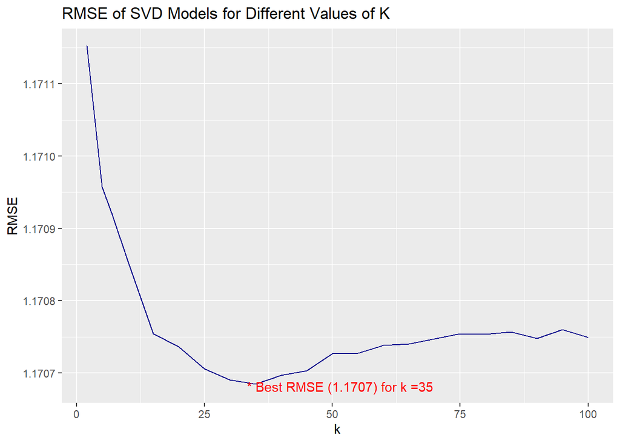

Figure 4. RMSE of SVD model for different values of K

```r
best_k = RMSE[which.min(RMSE$RMSE),"k"]
best_svdRMSE = round(RMSE[which.min(RMSE$RMSE),"RMSE"],4)
ggplot(RMSE, aes(x = k, y = RMSE)) + geom_line(color = "darkblue") +
  annotate(geom="text", x = best_k+16.56, y = min(RMSE$RMSE)-3e-6, color = "red",
           label=paste0("* Best RMSE (", best_svdRMSE,") for k =",best_k)) +
  labs(title = "RMSE of SVD Models for Different Values of K")
```

From figure 4 we see that SVD model has the best RMSE of 1.1707 for K = 35.

### 3.5 Tune parameter nn for UBCF model

```r
set.seed(1234)
scheme = evaluationScheme(ratings_matrix, method="split", train = 0.8, given=3, goodRating=0)
grid = c(5, 10, 20, 30, seq(40,200,20))
RMSE = data.frame(nn = rep(0, length(grid)), RMSE = rep(0, length(grid)))
for (i in 1:length(grid)) {
  model= list("UBCF" = list(name="UBCF", param=list(nn = grid[i])))
  res = evaluate(scheme, model, type = "ratings", progress = FALSE)
  RMSE[i,1] = grid[i]
  RMSE[i,2] = getConfusionMatrix(res[[1]])[[1]][1]
}
(RMSE %>% arrange(RMSE))[1,]
```

|  | nn | RMSE |
| --- | --- | --- |
| 1 | 200 | 1.10142 |

### 3.6 Plot the tuning graph for the parameter nn of UBCF model

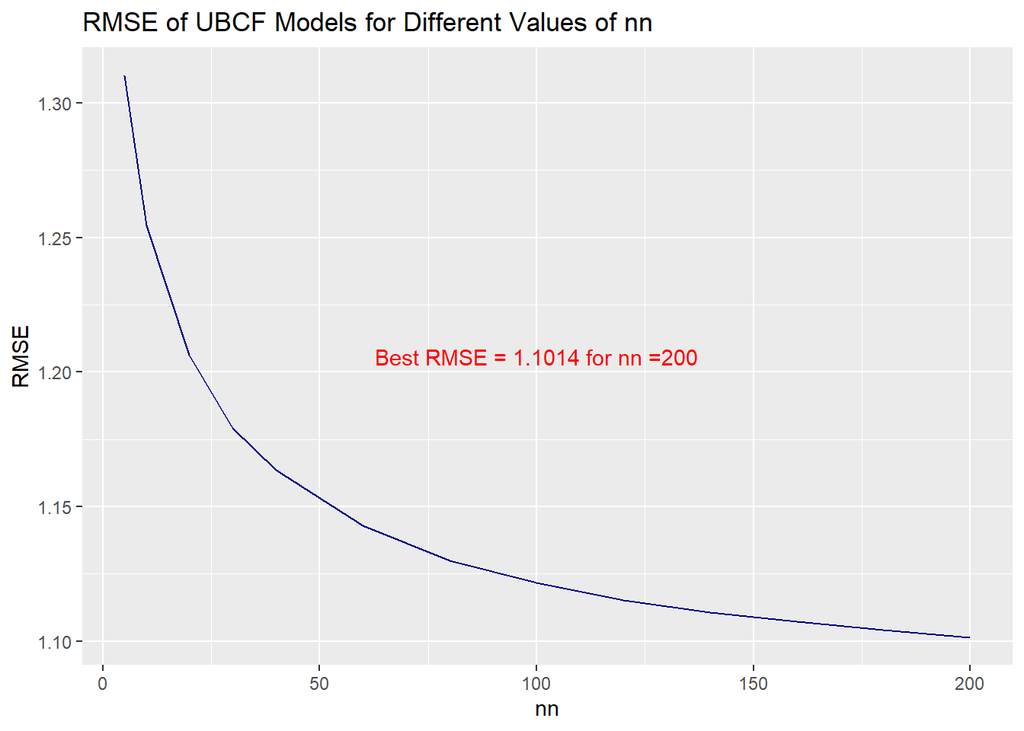

Figure 5. RMSE of UBCF model for different values of nn

```r
best_nn = RMSE[which.min(RMSE$RMSE),1]
best_ubcfRMSE = round(RMSE[which.min(RMSE$RMSE),"RMSE"],4)
ggplot(RMSE, aes(x = nn, y = RMSE)) + geom_line(color = "darkblue") +
  annotate(geom="text", x = 100, y = (max(RMSE$RMSE)+min(RMSE$RMSE))/2, color = "red",
           label=paste0("Best RMSE = ", best_ubcfRMSE," for nn =",best_nn)) +
  labs(title = "RMSE of UBCF Models for Different Values of nn")
```

From figure 5 we see that UBCF model has the best RMSE of 1.1014 for nn = 200.

### 3.7 Choose the final model

Based on the RMSE metric, the UBCF model performed better and was the algorithm chosen as final.

I saved the UBCF model locally as a rds file and then deployed in my github project folder: https://github.com/gcbacel/Movies

Reading the UBCF model from a .rds file in GitHub reduces significantly the time the Shiny App can provide a recommendation, avoiding the long processing time to train the model.

```r
modelubcf = Recommender(ratings_matrix, method = "UBCF", list(nn=200))
# save UBCF model to be used in the Shiny App.
saveRDS(modelubcf, "C:/Gunther/OneDrive - University of Illinois - Urbana/Documents/Github/Movies/modelubcf.rds")
```

### 3.8 Simulate results

```r
# create an empty 1xn matrix with all n movies item as columns, to be used as input matrix
rating_matrix = data.table(matrix(rep(NA,nrow(movies)), nrow = 1))
colnames(rating_matrix) =paste0("i", avg_rating$MovieID)

# Simulate a new user randomly rating movies
new_ratings = function(n = 10) {
  input = data.frame(matrix(rep(0, n*2), ncol=2))
  colnames(input) = c("MovieID", "Rating")
  for (i in 1:n) {
      input[i,1] = sample(movies$MovieID, 1)
      input[i,2] = round(runif(1,1, 5),0)
  }
  return(input)
}

movie_detail = function(vector_movies) {
  tmp = c(vector_movies)
  return (movies %>% filter(MovieID %in% tmp) %>% select (Title, Genres))
}

predict_top_movies = function(input_ratings) {
    input = as.matrix(rating_matrix)
    colnames(input) = paste0("i",movies$MovieID)
    for (i in 1:nrow(input_ratings)) {
        item = paste0("i", input_ratings$MovieID[i])
        input[1,item] = input_ratings$Rating[i]
    }
    recom = predict(modelubcf, as(input, "realRatingMatrix"), n=10)
    top10 = bestN(recom, n = 10)
    top10 = as(top10, "list")[[1]]
    top10 = as.numeric(str_sub(top10, 2, -1))
    return(top10)
}

input = new_ratings(n=6)
movie_detail(input$MovieID)
```

| Title | Genres |
| --- | --- |
| Crimson Tide (1995) | Drama\|Thriller\|War |
| Phantom, The (1996) | Adventure |
| Matilda (1996) | Children's\|Comedy |
| Field of Dreams (1989) | Drama |
| She's All That (1999) | Comedy\|Romance |
| Girlfight (2000) | Drama |

```r
pred = predict_top_movies(input)
movie_detail(pred)
```

| Title | Genres |
| --- | --- |
| Strawberry and Chocolate (Fresa y chocolate) (1993) | Drama |
| Faster Pussycat! Kill! Kill! (1965) | Action\|Comedy\|Drama |
| Close Shave, A (1995) | Animation\|Comedy\|Thriller |
| Four Days in September (1997) | Drama |
| Marnie (1964) | Thriller |
| Beloved (1998) | Drama |
| Wolf Man, The (1941) | Horror |
| Yojimbo (1961) | Comedy\|Drama\|Western |
| 42 Up (1998) | Documentary |
| Tumbleweeds (1999) | Drama |

# 4. Explanation of Shiny App

My shiny movie recommendation App is published at https://gunther-bacellar.shinyapps.io/ShinyApp

The code for this App is available in my github [HERE](https://github.com/gcbacel/Movies) and the code below is the same used by the App. The the core of App code was included in this session to provide some brief explanations.

As the UBCF algorithm provided better RMSE and showed relevant predictions in my tests, it was the algorithm choose to be included in the Shiny app.

The Shiny App implemented System II model (UBCF) through the tabs “STEP 1” and “STEP 2”, and implemented the System I in the “BONUS” tab.

To avoid to have always the same sequence of movies waiting to be rated by users, I shuffle the list of movies and show a new list every time the user open the App. The movie dataset only includes movies with at least 50 ratings to avoid users influence the movie ratings too much.

In the scenario that a user ask for recommendation without adding any new rating, the recommendation provides a fixed list of the movies with highest average ratings.

```r
# cleaning all variables in the system to simulate the code runnning in the Shiny app
rm(list = ls())
```

### 4.1 Code deployed in the App at Steps 1 and 2 (System II)

```r
library(dplyr)
library(ggplot2)
library(recommenderlab)
library(DT)
library(data.table)
library(reshape2)
library(tidyr)
library(stringr)
predict_top_movies = function(input_ratings) {
    input = as.matrix(rating_matrix)
    colnames(input) = paste0("i",movies$MovieID)
    for (i in 1:nrow(input_ratings)) {
        item = paste0("i", input_ratings$MovieID[i])
        input[1,item] = input_ratings$Rating[i]
    }
    recom = predict(modelubcf, as(input, "realRatingMatrix"), n=10)
    recom3 = bestN(recom, n = 10)
    top10 = as(recom3, "list")[[1]]
    top10 = as.numeric(str_sub(top10, 2, -1))
    return(top10)
}
myurl = "https://raw.githubusercontent.com/gcbacel/Movies/main/"
avg_rating = read.csv(paste0(myurl, "avg_rating.csv"))
movies = readLines(paste0(myurl, "movies.dat"))
movies = strsplit(movies, split = "::", fixed = TRUE, useBytes = TRUE)
movies = matrix(unlist(movies), ncol = 3, byrow = TRUE)
movies = data.frame(movies, stringsAsFactors = FALSE)
colnames(movies) = c('MovieID', 'Title', 'Genres')
movies$MovieID = as.integer(movies$MovieID)
movies$item = paste0("i",movies$MovieID)
movies = movies %>% inner_join(avg_rating, by = "MovieID")
movies$Title = iconv(movies$Title, "latin1", "UTF-8")
movies$Year = as.numeric(unlist(
    lapply(movies$Title, function(x) substr(x, nchar(x)-4, nchar(x)-1))))
small_image_url = "https://github.com/gcbacel/Movies/blob/main/Images/"
movies$image_url = sapply(movies$MovieID,
                          function(x) paste0(myurl, "Images/", x, '.jpg?raw=true'))
rating_matrix = data.table(matrix(rep(NA,nrow(movies)), nrow = 1))
colnames(rating_matrix) =paste0("i", avg_rating$MovieID)
modelubcf = readRDS(gzcon(url(paste0(myurl, "modelubcf.rds"))))
```

### 4.2 simulate some new ratings and show the recommendations

```r
# Simulate a new user adding some movie ratings
new_ratings = data.frame(MovieID = c(111, 1527, 3702, 3535, 1653),
                     Rating  = c(3, 5, 5, 3, 5))
movies %>% inner_join(new_ratings, by = "MovieID") %>% select (Title, Genres, Rating)
```

| Title | Genres | Rating |
| --- | --- | --- |
| Taxi Driver (1976) | Drama\|Thriller | 3 |
| Fifth Element, The (1997) | Action\|Sci-Fi | 5 |
| Gattaca (1997) | Drama\|Sci-Fi\|Thriller | 5 |
| American Psycho (2000) | Comedy\|Horror\|Thriller | 3 |
| Mad Max (1979) | Action\|Sci-Fi | 5 |

```r
pred = predict_top_movies(new_ratings)
movies %>% filter(MovieID %in% pred) %>% select (Title, Genres)
```

| Title | Genres |
| --- | --- |
| World of Apu, The (Apur Sansar) (1959) | Drama |
| Foreign Correspondent (1940) | Thriller |
| Stalker (1979) | Mystery\|Sci-Fi |
| Trust (1990) | Comedy\|Drama |
| Braindead (1992) | Comedy\|Horror |
| Paris, Texas (1984) | Drama |
| Four Days in September (1997) | Drama |
| Fanny and Alexander (1982) | Drama |
| Hands on a Hard Body (1996) | Documentary |
| Mummy, The (1959) | Horror |

### 4.3 Code deployed in the App as Bonus (System I)

As a fan of Sci-Fi movies, the App is recommending me these movies:

```r
genre = "Sci-Fi"
genre_result = (movies  %>%
                filter(Year>=1970, grepl(genre, Genres)) %>%
                arrange(-avg_rating))[1:10,]
genre_result[, c("Title", "Genres")]
```

|  | Title | Genres |
| --- | --- | --- |
| 1 | Star Wars: Episode IV - A New Hope (1977) | Action\|Adventure\|Fantasy\|Sci-Fi |
| 2 | Matrix, The (1999) | Action\|Sci-Fi\|Thriller |
| 3 | Star Wars: Episode V - The Empire Strikes Back (1980) | Action\|Adventure\|Drama\|Sci-Fi\|War |
| 4 | Blade Runner (1982) | Film-Noir\|Sci-Fi |
| 5 | Alien (1979) | Action\|Horror\|Sci-Fi\|Thriller |
| 6 | Terminator, The (1984) | Action\|Sci-Fi\|Thriller |
| 7 | Aliens (1986) | Action\|Sci-Fi\|Thriller\|War |
| 8 | Brazil (1985) | Sci-Fi |
| 9 | Ghost in the Shell (Kokaku kidotai) (1995) | Animation\|Sci-Fi |
| 10 | Clockwork Orange, A (1971) | Sci-Fi |

REFERENCES:

The Shiny App used as reference the code available for a Book Recommender System [HERE](https://github.com/pspachtholz/BookRecommender)